# Đinh Gia

Nhom 6

2023-10-30

### NHAP DU LIEU

```r
library(readxl)
X50_CP_HNX_ff <- read_excel("E:/Mo hinh dinh gia/AGroup/50-CP-HNX_ff.xlsx")
X50_CP_HNX <- read_excel("E:/Mo hinh dinh gia/AGroup/50-CP-HNX.xlsx")
Empty <- read_excel("E:/Mo hinh dinh gia/AGroup/Empty.xlsx")
head(X50_CP_HNX_ff)
```

```
## # A tibble: 6 × 3
##   Date       `r_HNX-Index`       r_f
##   <chr>              <dbl>     <dbl>
## 1 05/01/2022       0.0131  0.0000903
## 2 06/01/2022       0.00939 0.0000903
## 3 07/01/2022       0.0183  0.0000903
## 4 10/01/2022      -0.0224  0.0000903
## 5 11/01/2022      -0.00265 0.0000903
## 6 12/01/2022      -0.0167  0.0000903
```

```r
#attach(X50_CP_HNX_ff)
```

### 1.Tính chuỗi lợi suất

```r
for(j in 2:ncol(X50_CP_HNX)) {
  for(i in 2:nrow(X50_CP_HNX)) {
    a=X50_CP_HNX[[i,j]]
    b=X50_CP_HNX[[i-1,j]]
    Empty[[i,j]]=log(a/b)
  }
}

stock=Empty[-1,]
```

### 2.Mô hình Fama-French 3 nhân tố:

$r_i=alpha_i+beta1_i*(r_M-r_f)+beta2_i*SMB+beta3_i*HML+e_i$

$r_i$ : tỷ suất sinh lợi tài sản i

$r_M$ : tỷ suất sinh lợi thị trường

$r_f$ : lợi suất phi rủi ro

$SMB$ : nhân tố quy mô vốn hoá(Size Factor)

$HML$ : nhân tố chỉ số giá trị ghi sổ/giá trị thị trường(Book to Market)

$beta1_i;beta2_i;beta3_i$ : được kỳ vọng là dương

-Vấn đề đặt ra bây giờ là khi ứng dụng vào 50 cổ phiếu trên sàn giao dịch chứng khoán Hà Nội, ba nhân tố trong mô hình Fama-French có thật sự giải thích được sự thay đổi tỷ suất sinh lợi cổ phiếu.

-Có hay không những công ty có quy mô nhỏ sẽ cho tỷ suất sinh lợi cao hơn những công ty có quy mô lớn và việc những công ty có tỷ số Book/Market cao sẽ cho tỷ suất sinh lợi cao hơn những công ty có tỷ số này thấp như Fama-French đã phát biểu.

Vấn đề này sẽ được trả lời khi ta tiếp tục thực hiện các bước phân tích sau đây.

### 2.1. Tính toán các nhân tố

```r
library(readxl)
CS <- read_excel("R/CS.xlsx")
attach(CS)
attach(stock)
```

#### * Nhân tố quy mô vốn hoá (SMB)

-Tính chỉ số vốn hoá thị trường = khối lượng cổ phiếu đang lưu hành* giá cuối tháng 6

```r
CSVH<-CS$`Khối lượng CP lưu hành`*CS$`Giá cuối tháng 6`
CS1<-data.frame(CS,CSVH)
head(CS1)
```

```
##   Stock Khối.lượng.CP.lưu.hành      Vốn.CSH Tài.sản.vô.hình Giá.cuối.tháng.6
## 1   TTH               37374846 4.068710e+11               0             3100
## 2   FID               24715958 2.483844e+11               0             3200
## 3   SRA               43199974 6.299223e+11               0             6900
## 4   DL1              106236094 1.326969e+12       333801182             5000
## 5   ITQ               31843305 3.300238e+11      6660196800             4300
## 6   CTC               15799926 1.241249e+11      1101142284             4200
##   Market         CSVH
## 1   1800 115862022600
## 2   1700  79091065600
## 3   3000 298079820600
## 4   3000 531180470000
## 5   2600 136926211500
## 6   2000  66359689200
```

-Chia 2 danh mục trong đó danh mục 1 chứa các mã cổ phiếu có chỉ số vốn hoá thị trường lớn hơn median của dãy và danh mục 2 là các mã cổ phiếu còn lại

```r
VHL = c() # tạo vector để lưu các mã chứng khoán
VHN = c()

for (i in 1:length(CSVH)){
  if(CSVH[i]>median(CSVH)) {
    VHL<-c(VHL,i)
  }
  else {
    VHN <-c(VHN,i)
  }
}
```

```r
por_Big = c()
por_Small = c()
for ( i in VHL){
  por_Big<-c(por_Big,CS$Stock[i])
}
for ( i in VHN){
  por_Small<-c(por_Small,CS$Stock[i])
}
cbind(por_Big,por_Small)
```

```
##       por_Big por_Small
##  [1,] "NRC"   "TTH"
##  [2,] "BCC"   "FID"
##  [3,] "TIG"   "SRA"
##  [4,] "LAS"   "DL1"
##  [5,] "EVS"   "ITQ"
##  [6,] "BVS"   "CTC"
##  [7,] "IDJ"   "AMV"
##  [8,] "SHS"   "LIG"
##  [9,] "API"   "HAD"
## [10,] "TNG"   "MST"
## [11,] "VNR"   "HOM"
## [12,] "MBS"   "DXP"
## [13,] "TAR"   "AAV"
## [14,] "CSC"   "NSH"
## [15,] "PVS"   "IVS"
## [16,] "HUT"   "CMS"
## [17,] "NTP"   "TVD"
## [18,] "VCS"   "VGS"
## [19,] "THD"   "VC7"
## [20,] "VC3"   "BNA"
## [21,] "VFS"   "PVB"
## [22,] "DDG"   "APS"
## [23,] "KSF"   "PVC"
## [24,] "L14"   "MAC"
## [25,] "SCG"   "IDV"
```

-Tính lợi suất của 2 danh mục sau đó $SMB = r_S- r_B$

```r
dataB = data.frame(NRC,BCC,TIG,HUT,LAS,EVS,BVS,IDJ,SHS,API,TNG,VNR,MBS,TAR,CSC,PVS,NTP,VCS,THD,VC3,VFS,DDG,KSF,L14,SCG)
#head(dataB)
r_Big<-rowMeans(dataB)
dataS = data.frame(TTH,FID,SRA,DL1,ITQ,CTC,AMV,LIG,HAD,MST,HOM,DXP,AAV,NSH,IVS,CMS,VGS,VC7,BNA,PVB,APS,PVC,MAC,IDV,TVD)
r_Small<-rowMeans(dataS)
SMB=r_Small-r_Big
head(SMB)
```

```
## [1] -0.0009873598  0.0037899561  0.0088614668  0.0283514508 -0.0191950446
## [6] -0.0228536953
```

#### * Nhân tố giá trị sổ sách/giá trị thị trường

-Tính chỉ số giá trị sổ sách/giá trị thị trường (Book to Market)

```r
# Giá trị sổ sách =(VCSH-Tài sản vô hình)/Khối lượng CP lưu hành
Book = (CS$`Vốn CSH`-CS$`Tài sản vô hình`)/CS$`Khối lượng CP lưu hành`
BtM =Book/CS$Market
head(BtM)
```

```
## [1] 6.047903 5.911503 4.860514 4.162536 3.905707 3.893175
```

-Xếp hạng chỉ số Book to Market

```r
BtM <- BtM[order(BtM,decreasing = TRUE)]
BtM
```

```
##  [1] 6.0479031 5.9115032 4.8605142 4.1625361 3.9057074 3.8931750 3.7883268
##  [8] 3.7384395 3.4103695 3.3660004 3.0714236 2.9943514 2.8964604 2.7257549
## [15] 2.7188822 2.0913181 1.9297522 1.8446815 1.8378748 1.7992619 1.7720356
## [22] 1.6215150 1.5873430 1.5500130 1.4984998 1.4717724 1.4636957 1.4340959
## [29] 1.3809078 1.3622458 1.3563329 1.3553092 1.2946851 1.2310490 1.0915296
## [36] 1.0595316 1.0518449 1.0395641 0.8944534 0.8194743 0.7582239 0.6809499
## [43] 0.5411027 0.4779424 0.4750028 0.4555115 0.3238457 0.3143654 0.2538102
## [50] 0.1985538
```

-Chia 2 danh mục với danh mục High là 1/3 số mã CK có chỉ số BtM cao nhất và danh mục Low là 1/3 số mã CK có chỉ số BtM thấp nhất

```r
por_high = c()
por_low = c()
for ( i in 1:length(BtM)){
  if ( i <18){
    por_high= c(por_high,CS$Stock[i])
  }
  if(i>33){
    por_low = c(por_low,CS$Stock[i])
  }
}
cbind(por_high,por_low)
```

```
##       por_high por_low
##  [1,] "TTH"    "VNR"
##  [2,] "FID"    "MBS"
##  [3,] "SRA"    "TAR"
##  [4,] "DL1"    "MAC"
##  [5,] "ITQ"    "CSC"
##  [6,] "CTC"    "IDV"
##  [7,] "AMV"    "PVS"
##  [8,] "LIG"    "HUT"
##  [9,] "HAD"    "NTP"
## [10,] "MST"    "VCS"
## [11,] "NRC"    "THD"
## [12,] "HOM"    "VC3"
## [13,] "DXP"    "VFS"
## [14,] "AAV"    "DDG"
## [15,] "NSH"    "KSF"
## [16,] "BCC"    "L14"
## [17,] "IVS"    "SCG"
```

-Tính lợi suất 2 danh mục này sau đó tính : $HML = r_H - r_L$

```r
dataH = data.frame(TTH,FID,SRA,DL1,ITQ,CTC,AMV,LIG,HAD,MST,NRC,HOM,DXP,AAV,NSH,BCC,IVS)
dataL = data.frame(VNR,MBS,TAR,MAC,CSC,IDV,PVS,HUT,NTP,VCS,THD,VC3,VFS,DDG,KSF,L14,SCG)
r_High = rowMeans(dataH)
r_Low = rowMeans(dataL)
HML=r_High-r_Low
head(HML)
```

```
## [1] -0.0136731846  0.0073648837 -0.0006314481  0.0222186140 -0.0288844024
## [6] -0.0409233582
```

#### * Nhân tố thị trường( Market Factor )

```r
Market_Factor = X50_CP_HNX_ff$`r_HNX-Index`- X50_CP_HNX_ff$r_f
head(Market_Factor)
```

```
## [1]  0.013027275  0.009295961  0.018199239 -0.022512971 -0.002744504
## [6] -0.016777396
```

```r
X50_CP_HNX_ff<-data.frame(X50_CP_HNX_ff,Market_Factor,SMB,HML)
head(X50_CP_HNX_ff)
```

```
##         Date  r_HNX.Index          r_f Market_Factor           SMB
## 1 05/01/2022  0.013117553 9.027778e-05   0.013027275 -0.0009873598
## 2 06/01/2022  0.009386238 9.027778e-05   0.009295961  0.0037899561
## 3 07/01/2022  0.018289517 9.027778e-05   0.018199239  0.0088614668
## 4 10/01/2022 -0.022422694 9.027778e-05  -0.022512971  0.0283514508
## 5 11/01/2022 -0.002654227 9.027778e-05  -0.002744504 -0.0191950446
## 6 12/01/2022 -0.016687118 9.027778e-05  -0.016777396 -0.0228536953
##             HML
## 1 -0.0136731846
## 2  0.0073648837
## 3 -0.0006314481
## 4  0.0222186140
## 5 -0.0288844024
## 6 -0.0409233582
```

#### 2.2. Hồi quy mô hình

#### Ma trận tương quan giữa các nhân tố:

```r
cor(X50_CP_HNX_ff[,4:6])
```

```
##               Market_Factor       SMB       HML
## Market_Factor     1.0000000 0.2316264 0.3936433
## SMB               0.2316264 1.0000000 0.7992975
## HML               0.3936433 0.7992975 1.0000000
```

Ta thấy giá trị tuyệt đối của hệ số tương quan giữa các nhân tố vào khoảng [0.2, 0.8]. Trong đó giữa 2 nhân tố SMB và HML có mối tương quan cao nhất. Theo các giả thiết của mô hình đa nhân tố thì các nhân tố không có tương quan với nhau. Vậy liệu trên thị trường chứng khoán HNX các biến độc lập có thể cùng một lúc giải thích sự thay đổi của biến phụ thuộc (tỷ suất sinh lợi cổ phiếu) hay không?

```r
library(latex2exp)
library(zoo)
library(lmtest)
library(stargazer)
```

```r
library(ggplot2)
datanew<-data.frame(X50_CP_HNX_ff,stock[,-1])
head(datanew)
```

```
##         Date  r_HNX.Index          r_f Market_Factor           SMB
## 1 05/01/2022  0.013117553 9.027778e-05   0.013027275 -0.0009873598
## 2 06/01/2022  0.009386238 9.027778e-05   0.009295961  0.0037899561
## 3 07/01/2022  0.018289517 9.027778e-05   0.018199239  0.0088614668
## 4 10/01/2022 -0.022422694 9.027778e-05  -0.022512971  0.0283514508
## 5 11/01/2022 -0.002654227 9.027778e-05  -0.002744504 -0.0191950446
## 6 12/01/2022 -0.016687118 9.027778e-05  -0.016777396 -0.0228536953
##             HML         MAC         KSF          NSH          IVS         SCG
## 1 -0.0136731846  0.06637507  0.03320867  0.007604599 -0.016620881 -0.00645580
## 2  0.0073648837 -0.01851905  0.09462470  0.093931820 -0.005602256 -0.01435119
## 3 -0.0006314481  0.04567004  0.02817088 -0.035091320  0.005602256 -0.03885284
## 4  0.0222186140 -0.01801851 -0.10289442  0.000000000 -0.016901811 -0.01791916
## 5 -0.0288844024 -0.02765153 -0.02115823 -0.014388737 -0.034685558  0.01518318
## 6 -0.0409233582 -0.04785602 -0.02161559 -0.007272759  0.017493157 -0.02216157
##            FID          BNA          NRC         VGS          AAV          VFS
```

[output cut: 55 more lines]

#### Dùng vòng lặp for để ước lượng mô hình với từng biến phụ thuộc

```r
coef_table=data.frame() # tạo 1 bảng dữ liệu để lưu trữ các hệ số ước lượng
dependent=c(datanew[,7:56])
for (return in dependent){
  model <- lm(return~Market_Factor+SMB+HML,data = datanew)
  #print(summary(model))
  #stargazer(model,type = "text")
  coef_values<-coef(model)
  coef_table<-rbind(coef_table,coef_values)

}
colnames(coef_table)=c("alpha_i","beta_MarketFactor","beta_SMB","beta_HML")
# Sử dụng tập dữ liệu "coef_table" để ước lượng phần bù rủi ro nhân tố và các phần sau
head(coef_table)
```

```
##         alpha_i beta_MarketFactor     beta_SMB   beta_HML
## 1  0.0023837866         0.8890376  2.561450620 -1.2369677
## 2 -0.0002519259         0.2378145 -0.197886483 -0.1611583
## 3  0.0032167972         1.1374048  0.286267020  1.1095737
## 4  0.0007700349         0.9377463  0.001018681  0.7741092
## 5  0.0012399375         0.4534594  0.061792257  0.0482609
## 6  0.0010181358         1.1878662  0.660325590  0.8672210
```

```r
# Nhập dữ liệu 4 danh mục đại diện
por <- read_excel("E:/Mo hinh dinh gia/AGroup/por.xlsx")
datapor=data.frame(X50_CP_HNX_ff,por[5:8])
head(datapor)
```

```
##         Date  r_HNX.Index          r_f Market_Factor           SMB
## 1 05/01/2022  0.013117553 9.027778e-05   0.013027275 -0.0009873598
## 2 06/01/2022  0.009386238 9.027778e-05   0.009295961  0.0037899561
## 3 07/01/2022  0.018289517 9.027778e-05   0.018199239  0.0088614668
## 4 10/01/2022 -0.022422694 9.027778e-05  -0.022512971  0.0283514508
## 5 11/01/2022 -0.002654227 9.027778e-05  -0.002744504 -0.0191950446
## 6 12/01/2022 -0.016687118 9.027778e-05  -0.016777396 -0.0228536953
##             HML       r_porSH     r_porSL      r_porBL      r_porBH
## 1 -0.0136731846 -0.0001211915  0.02961111  0.009858372 -0.011764231
## 2  0.0073648837  0.0202402821 -0.01578573  0.010795469 -0.024020322
## 3 -0.0006314481  0.0121611951  0.03293765  0.008088600 -0.002974119
## 4  0.0222186140  0.0083387033  0.01742997 -0.021929202 -0.020721105
## 5 -0.0288844024 -0.0330514934 -0.01382577 -0.001514839 -0.022818280
## 6 -0.0409233582 -0.0391855123 -0.03766522  0.008032499 -0.031378685
```

#### 2.3. Hồi quy mô hình với các biến phụ thuộc lần lượt lợi suất của 4 danh mục đại diện (SL;SH;BL;BH)

Vì khó để đánh giá tác động của các nhân tố tới từng tài sản nên ta sẽ thông qua 4 danh mục đại diện để phân tích

```r
reg11=lm(data = datapor,r_porBH~Market_Factor)
reg21=lm(data = datapor,r_porBL~Market_Factor)
reg31=lm(data = datapor,r_porSH~Market_Factor)
reg41=lm(data = datapor,r_porSL~Market_Factor)
stargazer(reg11,reg21,reg31,reg41,type = "text")
```

```
##
## ===========================================================================
##                                            Dependent variable:
##                                --------------------------------------------
##                                 r_porBH     r_porBL     r_porSH    r_porSL
##                                   (1)         (2)         (3)        (4)
## ---------------------------------------------------------------------------
## Market_Factor                   1.161***    0.996***    1.334***  0.700***
##                                 (0.086)     (0.029)     (0.063)    (0.079)
##
## Constant                         -0.002      0.001*      -0.001     0.001
##                                 (0.002)     (0.001)     (0.001)    (0.002)
##
## ---------------------------------------------------------------------------
## Observations                      248         248         248        248
## R2                               0.426       0.831       0.642      0.241
## Adjusted R2                      0.424       0.830       0.641      0.238
## Residual Std. Error (df = 246)   0.026       0.009       0.019      0.024
## F Statistic (df = 1; 246)      182.603*** 1,210.149*** 441.911*** 77.954***
## ===========================================================================
## Note:                                           *p<0.1; **p<0.05; ***p<0.01
```

```r
reg12=lm(data = datapor,r_porBH~Market_Factor+SMB)
reg22=lm(data = datapor,r_porBL~Market_Factor+SMB)
reg32=lm(data = datapor,r_porSH~Market_Factor+SMB)
reg42=lm(data = datapor,r_porSL~Market_Factor+SMB)
stargazer(reg12,reg22,reg32,reg42,type = "text")
```

```
##
## =========================================================================
##                                           Dependent variable:
##                                ------------------------------------------
##                                 r_porBH    r_porBL    r_porSH    r_porSL
##                                   (1)        (2)        (3)        (4)
## -------------------------------------------------------------------------
## Market_Factor                   1.085***   0.998***   1.154***  0.578***
##                                 (0.086)    (0.029)    (0.042)    (0.074)
##
## SMB                             0.526***    -0.012    1.247***  0.849***
##                                 (0.138)    (0.047)    (0.068)    (0.119)
##
## Constant                         -0.001     0.001*     0.0003     0.002
##                                 (0.002)    (0.001)    (0.001)    (0.001)
##
## -------------------------------------------------------------------------
## Observations                      248        248        248        248
## R2                               0.458      0.831      0.850      0.371
## Adjusted R2                      0.454      0.830      0.848      0.366
## Residual Std. Error (df = 245)   0.026      0.009      0.013      0.022
## F Statistic (df = 2; 245)      103.641*** 602.821*** 691.499*** 72.256***
## =========================================================================
## Note:                                         *p<0.1; **p<0.05; ***p<0.01
```

```r
reg13=lm(data = datapor,r_porBH~Market_Factor+HML)
reg23=lm(data = datapor,r_porBL~Market_Factor+HML)
reg33=lm(data = datapor,r_porSH~Market_Factor+HML)
reg43=lm(data = datapor,r_porSL~Market_Factor+HML)
stargazer(reg13,reg23,reg33,reg43,type = "text")
```

```
##
## ===========================================================================
##                                            Dependent variable:
##                                --------------------------------------------
##                                 r_porBH    r_porBL     r_porSH     r_porSL
##                                   (1)        (2)         (3)         (4)
## ---------------------------------------------------------------------------
## Market_Factor                   0.827***   0.988***    0.959***   0.611***
##                                 (0.076)    (0.031)     (0.033)     (0.085)
##
## HML                             0.947***    0.023      1.064***   0.254***
##                                 (0.085)    (0.035)     (0.037)     (0.095)
##
## Constant                        -0.00003    0.001*     0.001**      0.001
##                                 (0.001)    (0.001)     (0.001)     (0.002)
##
## ---------------------------------------------------------------------------
## Observations                      248        248         248         248
## R2                               0.618      0.831       0.919       0.262
## Adjusted R2                      0.615      0.830       0.919       0.256
## Residual Std. Error (df = 245)   0.021      0.009       0.009       0.024
## F Statistic (df = 2; 245)      198.427*** 603.862*** 1,393.322*** 43.517***
## ===========================================================================
## Note:                                           *p<0.1; **p<0.05; ***p<0.01
```

```r
reg14=lm(data = datapor,r_porBH~SMB+HML)
reg24=lm(data = datapor,r_porBL~SMB+HML)
reg34=lm(data = datapor,r_porSH~SMB+HML)
reg44=lm(data = datapor,r_porSL~SMB+HML)
stargazer(reg14,reg24,reg34,reg44,type = "text")
```

```
##
## ========================================================================
##                                           Dependent variable:
##                                -----------------------------------------
##                                 r_porBH    r_porBL   r_porSH    r_porSL
##                                   (1)        (2)       (3)        (4)
## ------------------------------------------------------------------------
## SMB                            -1.590***  -0.460***   -0.077   1.284***
##                                 (0.204)    (0.170)   (0.170)    (0.214)
##
## HML                             2.197***  0.713***   1.528***   -0.193
##                                 (0.142)    (0.118)   (0.119)    (0.150)
##
## Constant                         -0.001    -0.001     -0.001    -0.0004
##                                 (0.002)    (0.001)   (0.001)    (0.002)
##
## ------------------------------------------------------------------------
## Observations                      248        248       248        248
## R2                               0.548      0.165     0.639      0.221
## Adjusted R2                      0.544      0.158     0.636      0.215
## Residual Std. Error (df = 245)   0.023      0.019     0.020      0.025
## F Statistic (df = 2; 245)      148.626*** 24.244*** 216.757*** 34.835***
## ========================================================================
## Note:                                        *p<0.1; **p<0.05; ***p<0.01
```

```r
reg1=lm(data = datapor,r_porBH~Market_Factor+SMB+HML)
reg2=lm(data = datapor,r_porBL~Market_Factor+SMB+HML)
reg3=lm(data = datapor,r_porSH~Market_Factor+SMB+HML)
reg4=lm(data = datapor,r_porSL~Market_Factor+SMB+HML)

stargazer(reg1,reg2,reg3,reg4,type = "text")
```

```
##
## =========================================================================
##                                           Dependent variable:
##                                ------------------------------------------
##                                 r_porBH    r_porBL    r_porSH    r_porSL
##                                   (1)        (2)        (3)        (4)
## -------------------------------------------------------------------------
## Market_Factor                   0.746***   0.982***   0.976***  0.705***
##                                 (0.069)    (0.031)    (0.032)    (0.076)
##
## SMB                            -1.316***    -0.098    0.283***  1.544***
##                                 (0.170)    (0.077)    (0.080)    (0.187)
##
## HML                             1.716***    0.080     0.898***  -0.648***
##                                 (0.125)    (0.057)    (0.059)    (0.138)
##
## Constant                         0.0003     0.001*     0.001*     0.001
##                                 (0.001)    (0.001)    (0.001)    (0.001)
##
## -------------------------------------------------------------------------
## Observations                      248        248        248        248
## R2                               0.694      0.832      0.923      0.423
## Adjusted R2                      0.690      0.830      0.922      0.416
## Residual Std. Error (df = 244)   0.019      0.009      0.009      0.021
## F Statistic (df = 3; 244)      184.110*** 404.149*** 977.140*** 59.638***
## =========================================================================
## Note:                                         *p<0.1; **p<0.05; ***p<0.01
```

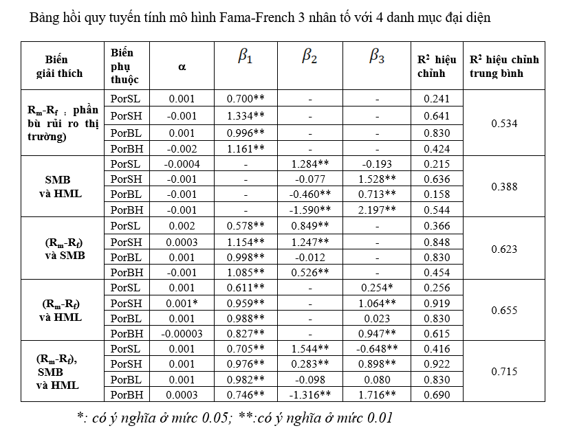

Kết quả tại bảng cho ta thấy sự tác động của từng nhân tố giải thích lên tỷ suất sinh lợi như sau:

- Nhóm ba yếu tố bao gồm yếu tố thị trường, yếu tố quy mô và yếu tố B/M (yếu tố giá trị) có ảnh hưởng đến tỷ suất sinh lợi cổ phiếu tại HNX. Kết quả chạy hồi quy mô hình gồm ba yếu tố trên cho giá trị R2 hiệu chỉnh trung bình 0,715. Đây là giá trị R2 hiệu chỉnh cao nhất khi so sánh với mô hình thiếu vắng một trong các yếu tố này. Các hệ số hồi quy của mô hình gồm ba biến gần như là có ý nghĩa ở mức 5%. Như vậy, ta cũng có thể nói rằng tỷ suất sinh lợi của cổ phiếu tại HNX ngoài việc chịu tác động khách quan của nhân tố thị trường còn bị tác động bởi những yếu tố thuộc về đặc tính của doanh nghiệp niêm yết như quy mô và tỷ số B/M.

-Trong ba yếu tố tác động đến tỷ suất sinh lợi thì yếu tố thị trường giữ vai trò quan trọng hơn cả. Điều này được thể hiện qua việc kết quả chạy hồi quy mô hình chỉ gồm một biến thị trường cho giá trị R2 hiệu chỉnh là 0.534 cao hơn so với 0.388 là giá trị R2 hiệu chỉnh của mô hình hồi quy gồm hai biến SMB (thể hiện quy mô) và HML (thể hiện tỷ số B/M). Mặt khác, tất cả các hệ số hồi quy của biến thị trường cho bốn danh mục đầu tư đều có ý nghĩa về mặt thống kê ở mức 05%

-Khi kết hợp biến thị trường và biến SMB hoặc biến HML đã làm tăng đáng kể giá trị R2 hiệu chỉnh so với khi chỉ có một biến thị trường. Điều này được thể hiện qua việc giá trị R2 hiệu chỉnh từ 0.534 cho một biến thị trường đã tăng lên thành 0.623 và 0.655 cho trường hợp kết hợp cả hai biến thị trường và biến SMB hoặc HML. Như vậy, ta cũng có thể thấy rằng yếu tố quy mô và yếu tố giá trị đã giữ một vai trò không nhỏ trong việc giải thích sự thay đổi tỷ suất sinh lợi tại sàn HNX trong khoảng thời gian nghiên cứu từ tháng 1/2022 - 12/2022.